# Cross-validation of regression models: mixed model examples (edited)

John Fox and Georges Monette

2023-10-10

The following artificial data set exemplifies a difference between cluster-based and individual-based cross-validation in hierarchical models.

It also shows how, in contrast with ordinary least-squares models, the variance at different levels of a hierarchical model need not necessarily become smaller as the model becomes larger.

In this example, the simplest random intercept model results in a between-cluster variance that is much smaller than that of a model that also includes $x$ as a predictor. Consequently, different methods of assessing model fit may result in different best models, underscoring the importance of assessing hierarchical models at different levels.

Adjusting the parameters generating this data can be used to create examples that illustrates problems of non-convergence with hierarchical models. Fitted models with relatively small between-cluster variance, even those using simple random intercept models, are prone to non-convergence due to the nature of optimizing algorithms used in `lme` and `lmer`.

In some contexts, non-convergence, can be viewed as a diagnostic of a poor model. However, with a simple random intercept model where it may indicate a small between-cluster variance, non-convergence is an annoyance because it would be statistically correct to report that the data are consistent with a zero between-cluster population variance, i.e. that observed between-cluster variance in the data can be explained by the between-individual variability within clusters. This leads to valid statistical inferences. Although the calculation of accurate p-values for hypotheses concerning random effects may be complicated by the fact that the estimated variance is at the boundary of the parameter space, the estimated variance-covariance matrix of fixed-effect parameters will generally be non-singular and may be used for valid Wald tests of linear hypotheses of fixed-effect parameters.

Using cross-validation based on fitting random subsets compounds the problem since subsets for which there is non-convergence cause the cross-validation to fail unless non-converging subsets are omitted, which may bias results since non-convergence is likely to be related to the estimated between-cluster variances.

Varying the parameter for between-cluster variance (`SDre` in the code below), will generate data sets with varying propensities to produce non-convergence. These data sets can be used to explore the consequences of non-convergence and to compare the performance of different optimizers.

At present, the results below are based on a data set that does not produce non-convergence and are limited to comparisons obtained by varying three factors:

- Three models: random intercept only, adding x as a predictor, and also adding the group means of x as a predictor,
- The method used for fitting: `lmer` in `lme4` or `lme` in `nlme`,
- Cross-validation resampling individual cases or resampling clusters.

Since the independence of clusters may be a reasonable assumption, as is the the independence of individual observations from the same cluster *conditional* on clusters, each form of resampling addresses the suitability of models to answer different questions. Results based on individual resampling generalize to new samples from the same clusters. Resampling clusters generalizes to new samples of clusters and cases.

We start by generating and plotting the data.

```r
# Generate data set

# Parameters:
set.seed(9665) # set.seed(123) # set.seed(9693)
Nb <- 10     # number of groups
Nw <- 5      # number of individuals within groups
Bb <- 0      # between-group regression coefficient on group mean
SDre <- 2.0  # between-group SD of random level relative to group mean of x
SDwithin <- 0.5  # within group SD
Bw <- 1  # within group effect of x

Data <- data.frame(
  group = factor(rep(1:Nb, each=Nw)),
  x = 20 + seq(1, Nb*Nw)
) |>
  within(
    {
      xm  <- ave(x, group, FUN = mean) # within-group mean
      y <- 10 +
        Bb * xm +                  # contextual effect
        Bw * (x - xm) +            # within-group effect
        SDre * rnorm(Nb)[group] +  # random level by group
        SDwithin * rnorm(Nb*Nw)    # random error within groups
    }
  )
```

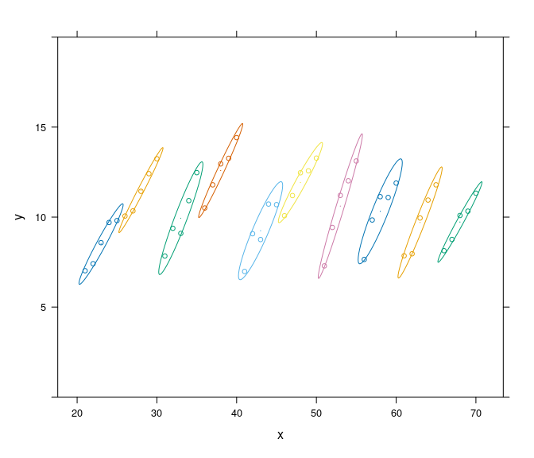

Hierarchical data set with 10 clusters

```r
plot <- xyplot(y ~ x, data=Data, group=group,
               ylim=c(0, 20),
               par.settings=list(superpose.symbol=list(pch=1, cex=0.7))) +
    layer(panel.ellipse(..., center.cex=0))
plot
```

The Y variable could represent scores on a programming aptitude test of 10 students of varying ages, each tested annually during a 5-year training program. The X variable is the age at which each test occurred.

```r
# random intercept only model:
fit0 <- lmer(y ~ 1 + (1|group), Data)

# effect of x and random intercept:
fit1 <- lmer(y ~ x + (1|group), Data)

# effect of x, mean of x, and random intercept:
fit2 <- lmer(y ~ x + xm + (1|group), Data)
```

We can compare estimated fixed-effect coefficients.

```r
compareCoefs(fit0,  fit1, fit2)
     Calls:
     1: lmer(formula = y ~ 1 + (1 | group), data = Data)
     2: lmer(formula = y ~ x + (1 | group), data = Data)
     3: lmer(formula = y ~ x + xm + (1 | group), data = Data)

                 Model 1 Model 2 Model 3
     (Intercept)   10.40    8.66   10.56
     SE             0.40    1.54    1.41

     x                    0.0384  0.9607
     SE                   0.0322  0.0520

     xm                          -0.9642
     SE                           0.0598
```

```r
Data <- within(Data, {
  fit_mod0.fe <- predict(fit0, re.form = ~ 0)
  fit_mod0.re <- predict(fit0)
  fit_mod1.fe <- predict(fit1, re.form = ~ 0)
  fit_mod1.re <- predict(fit1)
  fit_mod2.fe <- predict(fit2, re.form = ~ 0)
  fit_mod2.re <- predict(fit2)
})

Data_long <- reshape(Data, direction = "long", sep = ".",
              timevar = "effect", varying = grep("\\.", names(Data)))
Data_long$id <- 1:nrow(Data_long)
Data_long <- reshape(Data_long, direction = "long", sep = "_",
              timevar = "modelcode",  varying = grep("_", names(Data_long)))

Data_long$model <- factor(c("~ 1", "~ 1 + x", "~ 1 + x + xm")
                   [match(Data_long$modelcode, c("mod0","mod1","mod2"))])
```

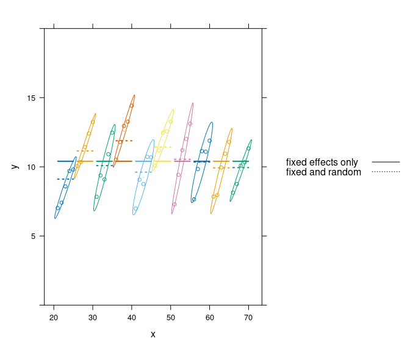

Fitted values with random intercept model

```r
(plot +
  xyplot(fit ~ x, subset(Data_long, modelcode == "mod0" &
                         effect == "fe"),
         groups=group, type="l", lwd=2) +
  xyplot(fit ~ x, subset(Data_long, modelcode == "mod0" &
                         effect == "re"),
         groups=group, type="l", lwd=2, lty=3)
) |> update(
  key=list(
    space="right",
    text=list(c("fixed effects only","fixed and random")),
    lines=list(lty=c(1, 3))))
```

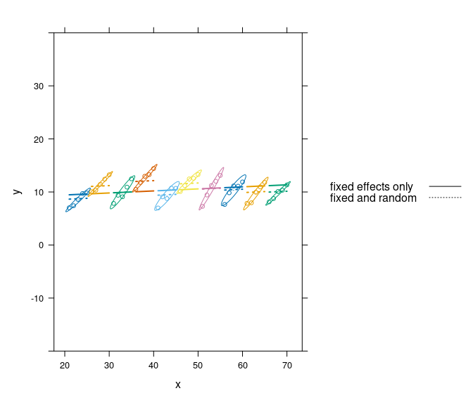

Fitted values with random intercept model and x as a predictor

```r
(plot +
  xyplot(fit ~ x, subset(Data_long, modelcode == "mod1" &
                         effect == "fe"),
         groups=group, type="l", lwd=2) +
  xyplot(fit ~ x, subset(Data_long, modelcode == "mod1" &
                         effect == "re"),
         groups=group, type="l", lwd=2, lty=3)
) |> update(
  ylim=c(-20, 40),
  key=list(
    space="right",
    text=list(c("fixed effects only","fixed and random")),
    lines=list(lty=c(1, 3))))
```

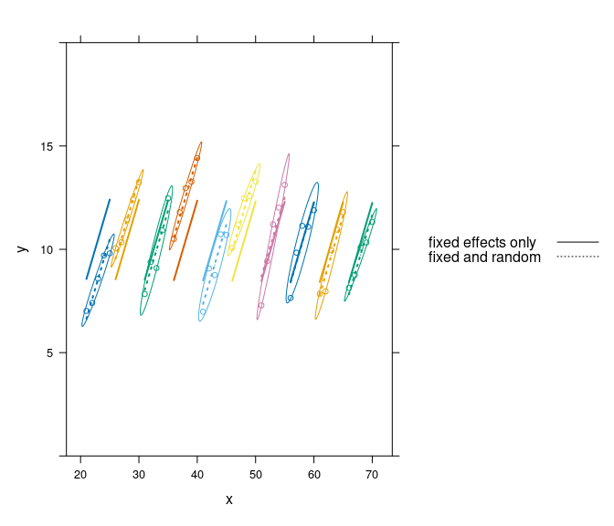

Fitted values with random intercept model and x and the group mean of x as predictors

```r
(plot +
  xyplot(fit ~ x, subset(Data_long, modelcode == "mod2" &

                           effect == "fe"),
         groups=group, type="l", lwd=2) +
  xyplot(fit ~ x, subset(Data_long, modelcode == "mod2" &
                         effect == "re"),
         groups=group, type="l", lwd=2, lty=3)
) |> update(
  ylim = c(0, 20),
  key=list(
    space="right",
    text=list(c("fixed effects only","fixed and random")),
    lines=list(lty=c(1, 3))))
```

### Cross-validation of models

We carry out cross-validation resampling individuals within clusters, based on fixed and predicted random effects, and resampling clusters, based on fixed effects only. In order to reduce between-model variability in comparisons of models, the `cv` method applied to the list of models created by the `models` function, performs cross-validation with the same training and validation sets for each model in order to reduce the between-model variability in the cross-validation criterion that stems from the random variation in training set selection.

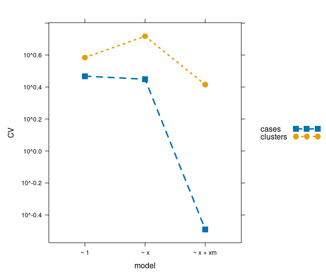

Cross-validation comparing random intercept models with varying fixed effects and with case- and cluster-based resampling.

```r
set.seed(673)

modlist <- models("~ 1"=fit0, "~ x"=fit1, "~ x + xm"=fit2)
cvs_cases <- cv(modlist, data=Data, seed=9693)
cvs_clusters <- cv(modlist, data=Data, cluster="group", seed=4576)

cvs_cases <- cvs_cases |> lapply(rbind) |>
  do.call(rbind, args = _) |> as.data.frame()
cvs_clusters <- cvs_clusters |> lapply(rbind) |>
  do.call(rbind, args = _) |> as.data.frame()

cvs_cases$modlist <- names(modlist)
cvs_clusters$modlist <- names(modlist)
cvs_cases$cv_method <- "cases"
cvs_clusters$cv_method <- "clusters"

dout <- within(
  as.data.frame(rbind(cvs_cases, cvs_clusters)),
  {
    model <- factor(modlist)
    CV <- as.numeric(as.character(`CV crit`))
  }
)

dout <- dout[order(dout$model), ]

xyplot(CV ~ model, data=dout, groups=cv_method,
       par.settings =
         list(superpose.line=list(lty=c(2, 3), lwd=3),
              superpose.symbol=list(pch=15:16,
                                    cex=1.5)),
       type="b",
       auto.key=TRUE,
       scales=list(y=list(log=TRUE)))
```